# Piloto e atualização dos resultados de MNEE para paisagens de 4x4 km2

Danilo Pereira Mori

2022-03-19

### Análise de escala de efeito e mudança na % de cobertura vegetal entre escalas

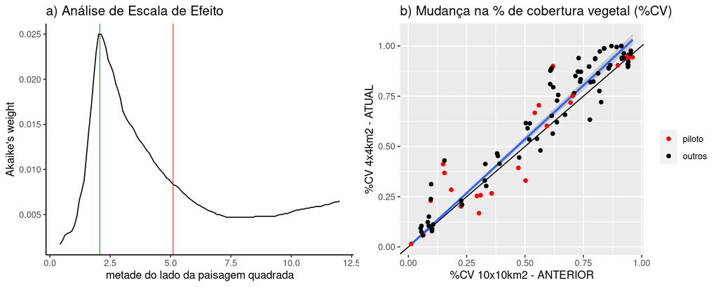

**Fig. 1** a) Análise de escala de efeito: No eixto y há o peso de evidência que a extensão espacial (eixo x) atribuiu à regressão do tipo S ~ offset(N) + p_i + p_i^2, S = riqueza de espécies, N = número de espécies, p_i = proporção de cobertura vegetal da extensão espacial i. b) Mudança na porcentagem de cobertura vegetal dos sítios: em x %CV com paisagens de 10.2x10.2 km2 e em y o mesmo para paisagens de 4.14x4.14 km2; a linha preta representa o 1:1 e a linha azul uma regressão linear com os novos pontos; os pontos vermelhos foram usados no piloto. A mudança na extensão espacial da paisagem resultou em aumento médio da %CV, apesar de alguns terem diminuído.

### Piloto

Fiz um sorteio de 30 pontos de uma distribuição uniforme entre 0 e 1 e selecionamos os sítios com menor diferença com a proporção de cobertura vegetal nas paisagens de 10x10km2. Excluindo os pontos repetidos, usei 23 sítios. Com esses pontos refiz as simulações coalescente para estimar U e predizer as SADs. Recortei os atuais mapas de 10x10km2 para mapas de 4x4km2.

#### Comparação paisagem de 10x10 km2 e de 4x4 km2

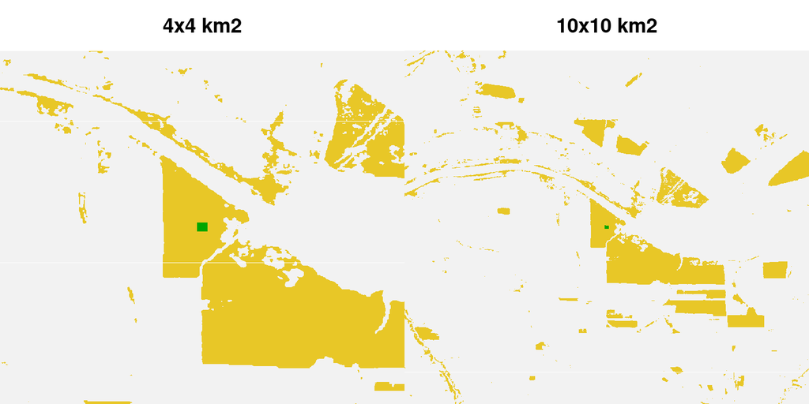

**Fig 2** Exemplo de recorte da paisagem ao redor.

#### Esforço computacional das simulações

**Tabela 1** Uso Computacional observado (minutos, n=23) e estimado (horas, n=103)

```
##        item minutos horas
## 1    Sim. U      73  5.45
## 2 Sim. SADs      80  5.97
## 3  teste KS      18  1.34
```

### Comparação variáveis respostas

#### Estimativas de U

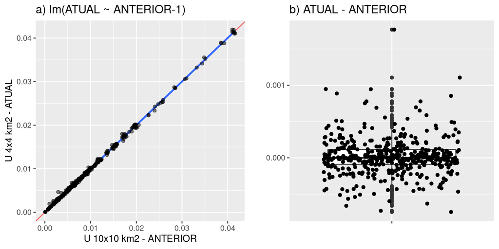

**Fig. 3** Gráficos exploratórios da média da taxa U, estimada por MNEE. a) a linha vermelha representa a relação 1:1 e a linha azul uma regressão linear padrão da função ggplot2::geom_smooth() sem intercepto. b) boxplot da diferença.

**Desvio-padrão das estimativas de U: U_med10x10 = anteriores; U_med = atuais; e diff_Umed = diferença entre atual e anterior**

```r
apply(df_Umed[,c("U_med_10x10","U_med","diff_Umed")],2,sd)
```

```
## U_med_10x10       U_med   diff_Umed
## 0.007941879 0.007941662 0.000255738
```

**Sumário padrão da regressão linear**

```r
summary(lm(U_med ~ U_med_10x10-1,data = df_Umed))
```

```
##
## Call:
## lm(formula = U_med ~ U_med_10x10 - 1, data = df_Umed)
##
## Residuals:
##        Min         1Q     Median         3Q        Max
## -7.614e-04 -9.437e-05 -5.150e-06  1.048e-04  1.764e-03
##
## Coefficients:
##             Estimate Std. Error t value Pr(>|t|)
## U_med_10x10 1.000899   0.001006   995.3   <2e-16 ***
## ---
## Signif. codes:  0 '***' 0.001 '**' 0.01 '*' 0.05 '.' 0.1 ' ' 1
##
## Residual standard error: 0.0002562 on 459 degrees of freedom
## Multiple R-squared:  0.9995, Adjusted R-squared:  0.9995
## F-statistic: 9.905e+05 on 1 and 459 DF,  p-value: < 2.2e-16
```

Os resultados sugerem que não há diferenças significativas entre as simulações feitas nas paisagens de 10.2x10.2 km2 e de 4.14x4.14 km2.

#### SADs preditas congruentes

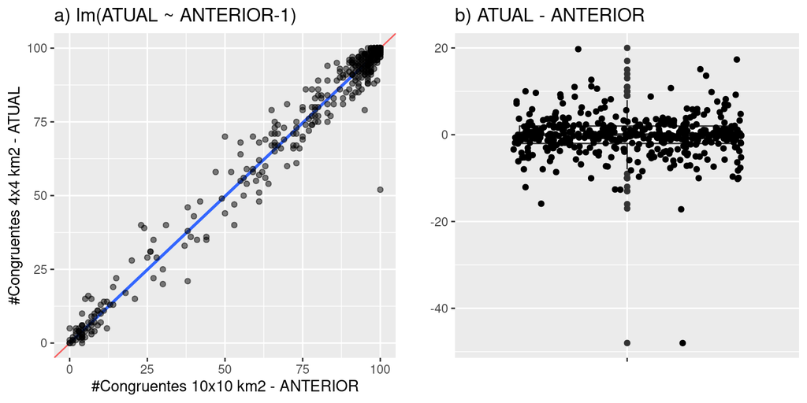

**Fig. 4** Gráficos exploratórios do número de SADs preditas por MNEE que são congruentes segundo o teste KS (#Congruentes) a) a linha vermelha representa a relação 1:1 e a linha azul uma regressão linear padrão da função ggplot2::geom_smooth() sem intercepto. b) boxplot da diferença. O ponto que mais diferiu ocorreu no cenário de limitação a dispersão menos severo.

```r
apply(df_SADsCongruentes[,3:5],2,sd)
```

```
##       n_nRef n_nRef_10x10    diff_SADs
##    32.513578    32.724264     4.800766
```

**Sumário padrão da regressão linear**

```r
summary(lm(n_nRef ~ n_nRef_10x10-1,data = df_SADsCongruentes))
```

```
##
## Call:
## lm(formula = n_nRef ~ n_nRef_10x10 - 1, data = df_SADsCongruentes)
##
## Residuals:
##     Min      1Q  Median      3Q     Max
## -47.537  -1.551   0.454   2.038  20.232
##
## Coefficients:
##              Estimate Std. Error t value Pr(>|t|)
## n_nRef_10x10 0.995367   0.002697     369   <2e-16 ***
## ---
## Signif. codes:  0 '***' 0.001 '**' 0.01 '*' 0.05 '.' 0.1 ' ' 1
##
## Residual standard error: 4.789 on 459 degrees of freedom
## Multiple R-squared:  0.9966, Adjusted R-squared:  0.9966
## F-statistic: 1.362e+05 on 1 and 459 DF,  p-value: < 2.2e-16
```

Apesar de ter aparente maior variabilidade, o número de SADs congruentes também é robusto à mudança na escala da paisagem.

#### Relação com outras preditoras

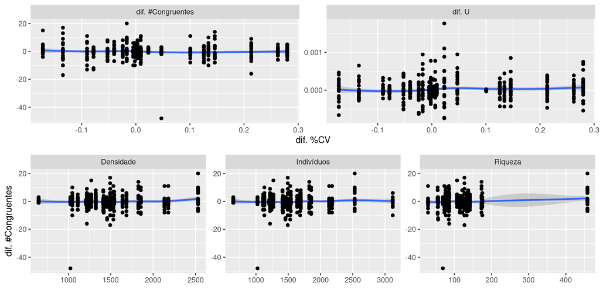

## Resultados Atualizados

### Probabilidade de SAD predita ser congruente

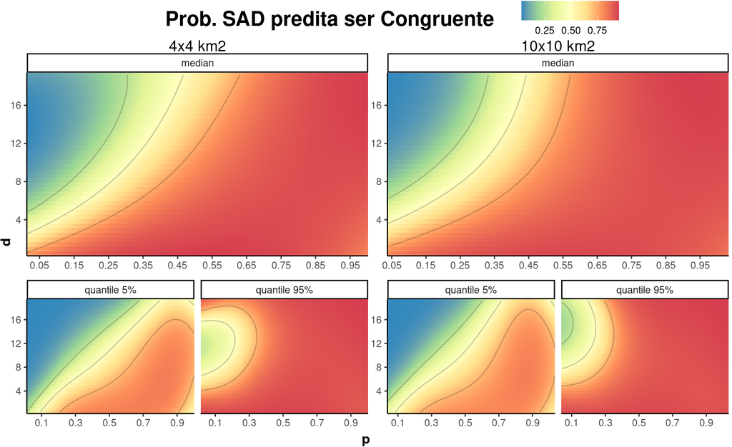

**Fig. 6** Comparação predição pelo modelo médio.

**Tabela 2** Número de SADs congruentes: R2 marginal e condicional atualizado e antigo

```
##   landscape    R2m    R2c      method
## 1       4x4 0.0890 0.9969 theoretical
## 2       4x4 0.0889 0.9962       delta
## 3     10x10 0.0894 0.9970 theoretical
## 4     10x10 0.0893 0.9962       delta
```

### U Estimado

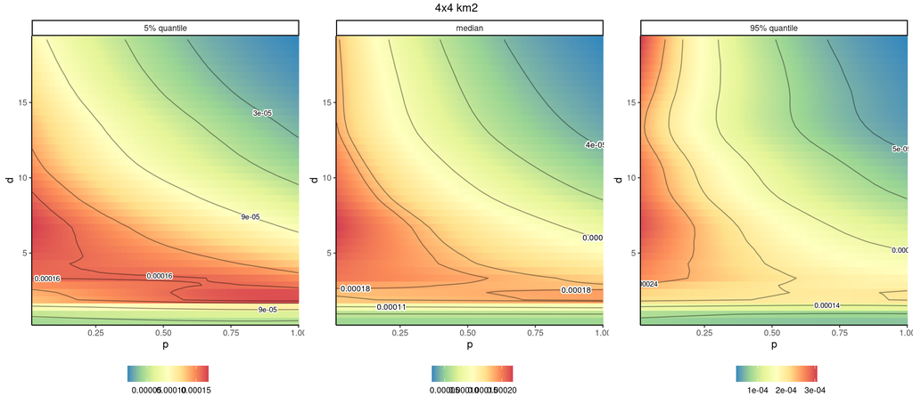

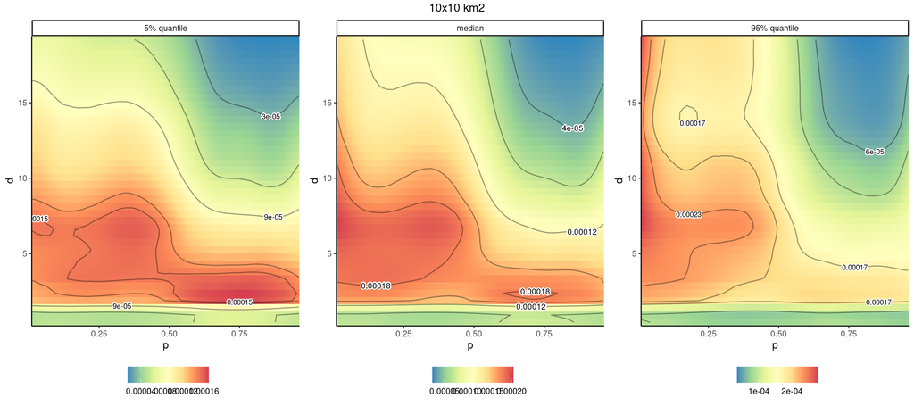

**Fig. 7** Predito pelo modelo estatístico para o U estimado nas paisagens atuais (4x4 km2) e anteriores (10x10 km2).

# Material Suplementar

### Códigos do sorteio de sítios ao longo do gradiente de cobertura vegetal nas paisagens de 10x10km2

```r
f_random_byVar <- function(x = df_resultados,
                           column_name = "p",
                           n_sample = 30,
                           i_seed = 260320223){
  # amostra de uma uniforme
  set.seed(i_seed)
  sample_points <- sort(runif(n = n_sample, min = 0, max = 1))
  # encontra os valores mais próoximos
  df_x <- filter(x,k==levels(x$k)[1],MN=="EE")
  f_index <- function(X=df_x,
                      name=column_name,
                      v_ref){
    which.min(abs(X[[column_name]] - v_ref))
  }
  # remove os sítios repetidos
  v_sites <- df_x[sapply(sample_points,function(y) f_index(v_ref=y)),"SiteCode"] %>% unique
  ## output:
  df_return <- filter(x,SiteCode %in% v_sites,MN=="EE")
  df_return$SiteCode <- factor(df_return$SiteCode)
  return(df_return)
}
df_piloto <- f_random_byVar(x=df_resultados)
write.csv(df_piloto,file = "./artigo_mestrado/1A.P_MOVER/Support Information/df_piloto.csv",
          row.names = FALSE)
```

### Códigos para recorte das paisagens

```r
f_recorte <- function(file_path){
  # matriz da paisagem de 10x10km:
  mat_paisagem <- read.table(file=file_path,
                             sep=" ",
                             header=TRUE) %>%
    as.matrix
  #redução proporcional no número de linhas e colunas da matriz:
  v_dim_novo <- dim(mat_paisagem) - round(dim(mat_paisagem) * (4.14/10.2),0)
  v_dim <- dim(mat_paisagem)
  # recorte:
  mat_paisagem_output <- mat_paisagem[floor(v_dim_novo[1]/2):(v_dim[1]-1-ceiling(v_dim_novo[1]/2)),
                                      floor(v_dim_novo[2]/2):(v_dim[2]-1-ceiling(v_dim_novo[2]/2))]
  ## outputs:
  # salva a nova paisagem
  write.table(mat_paisagem_output,
              file=gsub("dados_para_iniciar_artigo",
                        "piloto_MNEE_4x4km",
                        file_path),
              sep=" ",
              row.names = FALSE,col.names = FALSE)
  tree.cover <- as.vector(mat_paisagem_output)
  p <- 1 - length(tree.cover[tree.cover==0])/length(tree.cover)
  # e retorna a atual proporção de cobertura vegetal
  return(p)
}
registerDoMC(3)
p_4x4 <- aaply(df_$txt.name,1,f_recorte,.parallel = TRUE)
```